# Uso básico de R

Jorge Luis Gómez

24 August, 2022

# 1 Introducción

Originalemente, R se generó como un lenguaje enfocado para el cómputo estadístico y es muy similar al lenguaje S; no obstante, este lenguaje ha visto su desarrollo a una variedad de aplicaciones como la bioinformática y la ciencia de datos [^1]. R cuenta con una gran cantidad de técnicas estadísticas y para la generación de gráficas que le permite ser una de las herramientas más utilizadas en la bioinformática actual [^2].

El siguiente documento es solo una pequeña introducción al lenguaje R basado en la experiencia de los estudiantes que han generado este trabajo, así como de aquellos que seguirán refinando este trabajo. Si tienes dudas concretas que no estén en esta introducción, no tengas miedo de preguntarle a tus docentes. Si así lo prefieres, también puedes buscar por tu propia cuenta o basar tus esfurzos en recursos tales como los que mostramos en esta sección.

**Cabe recalcar que la mayoría de los recursos habidos están en inglés, por lo que algunos de los ejemplos o conceptos se manejarán en dicho idioma para facilitar su búsqueda**

# 2 Tipos de datos

De primera instancia, vamos a conocer algunos de los tipos de datos que pueden existir en R. Cada uno de estos tipos tienen sus ventajas, deventajas, usos y momentos adecuados en los cuales será más conveniente usar uno por sobre otro, pero no te preocupes, esto mejorará conforme la experiencia. En la siguiente tabla te presentamos algunos de los tipos de datos más básicos que utilizarás en R.

| Tipo de dato | Ejemplo |
| --- | --- |
| numeric | 64.3 |
| integer | 12 |
| logical | TRUE |
| character | “apple” |

## 2.1 Numeric

Este tipo de dato representa todos los datos numéricos, tengan decimales o no. A continuación veremos un ejemplo.

```r
altura <- 1.75
peso <- 79
```

```r
print(class(altura))
```

```
## [1] "numeric"
```

```r
print(class(peso))
```

```
## [1] "numeric"
```

En este punto es importante denotar algunas cosas. En la siguiense sección veremos los objetos `integer`, los cuales son relativamente similares, pero debe de quedar en claro que los objetos `numeric` representan cualquier número real, más no aquellos imaginarios.

De la misma manera, vemos el uso de dos funciones útiles, `print()` y `class()`. Estas funciones lo que hacen es imprimir/visualizar un objeto y decirte el tipo de dicho objeto, respectivamente.

## 2.2 Integer

Este tipo de dato es muy parecido al numérico que recién vimos; sin embargo, tiene una diferencia clave **no considera decimales**. En otras palabras, solo puede manejar números enteros, sean negativos o positivios. En ocasiones, cuando asignamos un valor a nuestro objeto o variable, pese a ser un número entero, lo considera `numeric`, por lo que se puede usar el sufijo `L` para denotarlo.

```r
inte <- 16L
```

```r
print(class(inte))
```

```
## [1] "integer"
```

## 2.3 Logical

Si llevaste en algún punto de tu formación, temas de lógica Booleana, este tipo de dato será sencillo para ti. En este caso, los valores de este tipo de datos solo pueden ser dos: **TRUE** o **FALSE** (verdadera y falso). Este tipo de dato se obtiene tras evaluar condiciones o al poner el input de manera directa. Podemos ver unos ejemplos a continuación.

```r
# Evaluar una condición

res <- 2>1
print(class(res))
```

```
## [1] "logical"
```

```r
print(res)
```

```
## [1] TRUE
```

```r
# Asignar el input de manera directa

res <- FALSE
print(class(res))
```

```
## [1] "logical"
```

```r
print(res)
```

```
## [1] FALSE
```

## 2.4 Character

Este tipo de dato es igualmente muy común y conformará parte esencial de tus trabajos y tareas que desarrollarás en el lenguaje R. En particular, este tipo de dato se refiere a todos aquellos que sean caracteres simples o *strings* completos de caracteres.

```r
# ejemplo de caracter aislado

cha <- "A"

print(class(cha))
```

```
## [1] "character"
```

```r
# ejemplo de string de caracteres

stg <- "string"

print(class(stg))
```

```
## [1] "character"
```

# 3 Data structures

Las estructuras de datos se refiere a un modo particular en el que se organizan datos para poder manipularlos de manera más eficiente. La idea es tener estructuras especializadas para las diferentes tareas que se pueden realizar no solo en R, sino, que en los lenguajes de programación en general. Básicamente, podemos clasificar las estructuras según sus dimensiones (1D, 2D nD). Si bien se pueden organizar según sus dimensiones, estas estructuras de datos se pueden conformar por todos los tipos de datos que se discutieron anteriormente y más. De forma común no se mezclan todos los tipos de dato en una sola estructura, pero no podemos decir realmente que son inexistentes [^3].

En particular, esta introducción discutirá algunas de las estructuras de datos más comunes. A continuación aprenderemos acerca de vectores, listas, dataframes y matrices.

## 3.1 Vectores

Un vector, dicho de manera simple, es una colección ordenada de una longitud *n* que se conforma por cualquier tipo de dato básico. Este tipo de estructura de dato debe de contener la misma clase de dato, por lo que se considera que es homogéneo.

La forma más sencilla de generar un vector en R es a través del uso de la función `c()`. **Cada elemento dentro de nuestro vector, el cual es unidimensional, debe de estar sperado por una coma**, de lo contrario, R nos arrojará un error que no se puede leer el vector y no podremos guardar datos ni asignar objetos o variables.

```r
first_vector <- c(1,2,3,4,5,5,2,3,4,2)

first_vector
```

```
##  [1] 1 2 3 4 5 5 2 3 4 2
```

Como se acaba de demostrar, no siempre es necesario usar la función `print()` para imprimir nuestro objeto; sin embargo, a lo largo de esta guía se usará para señalar de manera explícita que buscamos imprimir nuestro objeto. Esto solo fue una demostración.

Ahora, una parte importante de los vectores, es la longitud de los mismos, por lo que la función `length()` será muy útil desde los niveles más básicos, hasta lo más avanzado.

```r
print(length(first_vector))
```

```
## [1] 10
```

## 3.2 Listas

Las listas son otro tipo de estructura de dato que organiza de manera ordenada una colección de objetos. A diferencia de los vectores, las listas pueden contener varios tipos de datos, por lo que se consideran heterogéneas. Estas estructuras son unidimensionales, pero contiene una diferencia importante; los elementos dentro de la lista pueden ser n-dinemsionales. Puede contener matrices, caracteres, vectores, etc.

A continuación vamos a generar una lista de manera “directa” en una sola línea de código en esta ocasión.

```r
lst <- list("a"=2.5, "b"=TRUE, "c"=1:3, "nombre"="Jorge", "vec"=c("a","b"))

print(class(lst))
```

```
## [1] "list"
```

```r
print(lst)
```

```
## $a
## [1] 2.5
##
## $b
## [1] TRUE
##
## $c
## [1] 1 2 3
##
## $nombre
## [1] "Jorge"
##
## $vec
## [1] "a" "b"
```

El modo en que se muestra es el ID de cada elemento y posteriormente muestra la información que está contenida en la etiqueta de la lista que le asignamos.

## 3.3 Dataframes

Los dataframes sin objetos en los cuales podemos almacenar información de manera tabular, es decir, en forma de tabla. Este tipo de estructura es altamente utilizado en una gran cantidad de procesos, pipelines, funciones, etc., por lo que es importante saber su estructura y cómo se generan. Estos objetos son 2-D y pueden contener diferentes tipos de datos, lo que los hace heterogéneas; sin embargo, las columnas deben de contener el mismo tipo de datos a lo largo de sus renglones, aun cuando todas las columnas tengan diferentes tipos de dato.

Ahora aprovecharemos este espacio para incluir un aspecto importante que puede servir para practicar, o cuando tengas más experiencia, incluso tomar datos directamente de paquetes para hacer pruebas. Accederemnos a bases de datos pre-cargadas dentro de R.

```r
data()
```

Este comando habre en una nueva pestaña con las bases de datos que están pre-cargadas. En este caso, usaremos una de las más comúnes, `iris`.

```r
data("iris")
```

Ahora, ya veremos el dataframe que contiene esta base de datos.

```r
print(head(iris))
```

```
##   Sepal.Length Sepal.Width Petal.Length Petal.Width Species
## 1          5.1         3.5          1.4         0.2  setosa
## 2          4.9         3.0          1.4         0.2  setosa
## 3          4.7         3.2          1.3         0.2  setosa
## 4          4.6         3.1          1.5         0.2  setosa
## 5          5.0         3.6          1.4         0.2  setosa
## 6          5.4         3.9          1.7         0.4  setosa
```

Como vemos, tenemos 5 columnas con distintos datos, cada una con diferente nombre y la última tiene un tipo de dato diferente. De igual manera podemos ver el uso de una función útil, la cual es `head()`, esta función nos permite ver los primeros renglones de un dataframe, matrix o caulquier objeto que tenga varios renglones. De este modo, igual existe la función `tail()` la cual nos muestra los últimos renglones de nuestros datos.

```r
print(tail(iris))
```

```
##     Sepal.Length Sepal.Width Petal.Length Petal.Width   Species
## 145          6.7         3.3          5.7         2.5 virginica
## 146          6.7         3.0          5.2         2.3 virginica
## 147          6.3         2.5          5.0         1.9 virginica
## 148          6.5         3.0          5.2         2.0 virginica
## 149          6.2         3.4          5.4         2.3 virginica
## 150          5.9         3.0          5.1         1.8 virginica
```

Una vez quee ya vimos cómo es que se generan estas estructuras, vamos a ver cómo podemos formar las propias.

```r
df_1 <- data.frame(
  "number" = 1:10,
    "name" = c("one","two","tres","quatre","cinq","roku","nana","ocho","neuf","dix"),
    "numeric" = c(1.1,2.2,3.3,4.4,5.5,6.6,7.7,8.8,9.9,10.1)
  )

print(df_1)
```

```
##    number   name numeric
## 1       1    one     1.1
## 2       2    two     2.2
## 3       3   tres     3.3
## 4       4 quatre     4.4
## 5       5   cinq     5.5
## 6       6   roku     6.6
## 7       7   nana     7.7
## 8       8   ocho     8.8
## 9       9   neuf     9.9
## 10     10    dix    10.1
```

```r
print(class(df_1))
```

```
## [1] "data.frame"
```

## 3.4 Matrices

Este tipo de estructura tiene un solo tipo de dato, por lo que se considera homogénea. Así como en matemáticas, las matrices son muy usadas en este lenguaje, por la propia naturaleza con la que se creó y se mencionó en la introducción, por lo que los datos en las matrices son numéricos y se trabaja con ellos en este modo[^4]. El modo de leer una matriz, así como un dataframe, se hace leyendo primero el renglón y luego la clumna (x,y).

Existen varios modos de generar matrices desde cero, así que en este caso veremos cómo e que se hace en una sola línea de código. Para este fin, usaremos la función `matrix()` con la cual podemos crear nuestras matrices.

```r
mat_1 <- matrix(1:10)

print(mat_1)
```

```
##       [,1]
##  [1,]    1
##  [2,]    2
##  [3,]    3
##  [4,]    4
##  [5,]    5
##  [6,]    6
##  [7,]    7
##  [8,]    8
##  [9,]    9
## [10,]   10
```

Al observar este ejemplo, creamos de manera directa una matriz con una sola columna, pero con 10 renglones. Ahora veremos cómo se hacen varias columnas con varios renglones, asignando el número de dichos elementos que deseamos conformen nuestra matriz.

```r
mat_2 <- matrix(1:12, nrow=4,ncol=3)

print(mat_2)
```

```
##      [,1] [,2] [,3]
## [1,]    1    5    9
## [2,]    2    6   10
## [3,]    3    7   11
## [4,]    4    8   12
```

En este caso, asignamos 12 elementos numéricos en cuatro renglones y tres columnas. Es necesario recordar que los elementos deben de ser repartibles en el número de columnas y renglones que escogimos, de otro modo se omitirán o repitirán datos.

```r
mat_3 <- matrix(1:2, nrow=4,ncol=3)

print(mat_3)
```

```
##      [,1] [,2] [,3]
## [1,]    1    1    1
## [2,]    2    2    2
## [3,]    1    1    1
## [4,]    2    2    2
```

```r
mat_4 <- matrix(1:20, nrow=4,ncol=3)
print(mat_4)
```

```
##      [,1] [,2] [,3]
## [1,]    1    5    9
## [2,]    2    6   10
## [3,]    3    7   11
## [4,]    4    8   12
```

# 4 Manipular objetos

Ya hemos visto varias de las estructuras y tipos de objetos que podemos utilizar en R; sin embargo, esto es un conocimiento limitado, ya que el verdadero uso de un lenguaje es la capacidad de maniuplar y analizar la ifnromación y objetos que tenemos. En este sentido vamos a aprender a acceder a ciertos puntos espec´+ificos de información, añadir, eliminar, etc. Dicho de manera sencilla, veremos algunos ejemplos de usos un poco más reales de lo que se hace con R.

## 4.1 Seleccionar columnas/renglones

Los dataframes y matrices que hemos visto anteriormente tienen dimensiones en las que podemos comunicarnos de manera sencilla con renglones y columnas. Esta estructura de nuestros datos hace que sea necesario, en algunos casos, poder seleccionar que se visualice o guarde en un objeto, solo ciertas partes de nuestros datos originales.

```r
print(mtcars)
```

```
##                      mpg cyl  disp  hp drat    wt  qsec vs am gear carb
## Mazda RX4           21.0   6 160.0 110 3.90 2.620 16.46  0  1    4    4
## Mazda RX4 Wag       21.0   6 160.0 110 3.90 2.875 17.02  0  1    4    4
## Datsun 710          22.8   4 108.0  93 3.85 2.320 18.61  1  1    4    1
## Hornet 4 Drive      21.4   6 258.0 110 3.08 3.215 19.44  1  0    3    1
## Hornet Sportabout   18.7   8 360.0 175 3.15 3.440 17.02  0  0    3    2
## Valiant             18.1   6 225.0 105 2.76 3.460 20.22  1  0    3    1
## Duster 360          14.3   8 360.0 245 3.21 3.570 15.84  0  0    3    4
## Merc 240D           24.4   4 146.7  62 3.69 3.190 20.00  1  0    4    2
## Merc 230            22.8   4 140.8  95 3.92 3.150 22.90  1  0    4    2
## Merc 280            19.2   6 167.6 123 3.92 3.440 18.30  1  0    4    4
## Merc 280C           17.8   6 167.6 123 3.92 3.440 18.90  1  0    4    4
## Merc 450SE          16.4   8 275.8 180 3.07 4.070 17.40  0  0    3    3
## Merc 450SL          17.3   8 275.8 180 3.07 3.730 17.60  0  0    3    3
## Merc 450SLC         15.2   8 275.8 180 3.07 3.780 18.00  0  0    3    3
## Cadillac Fleetwood  10.4   8 472.0 205 2.93 5.250 17.98  0  0    3    4
## Lincoln Continental 10.4   8 460.0 215 3.00 5.424 17.82  0  0    3    4
## Chrysler Imperial   14.7   8 440.0 230 3.23 5.345 17.42  0  0    3    4
## Fiat 128            32.4   4  78.7  66 4.08 2.200 19.47  1  1    4    1
## Honda Civic         30.4   4  75.7  52 4.93 1.615 18.52  1  1    4    2
## Toyota Corolla      33.9   4  71.1  65 4.22 1.835 19.90  1  1    4    1
## Toyota Corona       21.5   4 120.1  97 3.70 2.465 20.01  1  0    3    1
## Dodge Challenger    15.5   8 318.0 150 2.76 3.520 16.87  0  0    3    2
## AMC Javelin         15.2   8 304.0 150 3.15 3.435 17.30  0  0    3    2
## Camaro Z28          13.3   8 350.0 245 3.73 3.840 15.41  0  0    3    4
## Pontiac Firebird    19.2   8 400.0 175 3.08 3.845 17.05  0  0    3    2
## Fiat X1-9           27.3   4  79.0  66 4.08 1.935 18.90  1  1    4    1
## Porsche 914-2       26.0   4 120.3  91 4.43 2.140 16.70  0  1    5    2
## Lotus Europa        30.4   4  95.1 113 3.77 1.513 16.90  1  1    5    2
## Ford Pantera L      15.8   8 351.0 264 4.22 3.170 14.50  0  1    5    4
## Ferrari Dino        19.7   6 145.0 175 3.62 2.770 15.50  0  1    5    6
## Maserati Bora       15.0   8 301.0 335 3.54 3.570 14.60  0  1    5    8
## Volvo 142E          21.4   4 121.0 109 4.11 2.780 18.60  1  1    4    2
```

Como vemos, nuestro objeto `mtcars` es un data.frame con información relevante de motores de ciertos vehículos y su rendimiento específico. Ahora, digamos, que solo nos interesa saber cuántas millas por galón de gasolina rinde cada motor, así que lo vamos a aislar.

```r
mtcars["mpg"]
```

```
##                      mpg
## Mazda RX4           21.0
## Mazda RX4 Wag       21.0
## Datsun 710          22.8
## Hornet 4 Drive      21.4
## Hornet Sportabout   18.7
## Valiant             18.1
## Duster 360          14.3
## Merc 240D           24.4
## Merc 230            22.8
## Merc 280            19.2
## Merc 280C           17.8
## Merc 450SE          16.4
## Merc 450SL          17.3
## Merc 450SLC         15.2
## Cadillac Fleetwood  10.4
## Lincoln Continental 10.4
## Chrysler Imperial   14.7
## Fiat 128            32.4
## Honda Civic         30.4
## Toyota Corolla      33.9
## Toyota Corona       21.5
## Dodge Challenger    15.5
## AMC Javelin         15.2
## Camaro Z28          13.3
## Pontiac Firebird    19.2
## Fiat X1-9           27.3
## Porsche 914-2       26.0
## Lotus Europa        30.4
## Ford Pantera L      15.8
## Ferrari Dino        19.7
## Maserati Bora       15.0
## Volvo 142E          21.4
```

En el caso anterior acabamos de ver cómo es que seleccionamos la columna que nos interesa, en este caso *mpg*. Es posible acceder a columnas específcas con el uso de corchetes **[]**. Dentro de estos corchetes podemos escribir los nombres de las columnas que queremos obtener, esto si sabemos el nombre; pero no solo se puede hacer con el nombre, esto puede hacerse con los números de igual medida.

```r
mtcars[1]
```

```
##                      mpg
## Mazda RX4           21.0
## Mazda RX4 Wag       21.0
## Datsun 710          22.8
## Hornet 4 Drive      21.4
## Hornet Sportabout   18.7
## Valiant             18.1
## Duster 360          14.3
## Merc 240D           24.4
## Merc 230            22.8
## Merc 280            19.2
## Merc 280C           17.8
## Merc 450SE          16.4
## Merc 450SL          17.3
## Merc 450SLC         15.2
## Cadillac Fleetwood  10.4
## Lincoln Continental 10.4
## Chrysler Imperial   14.7
## Fiat 128            32.4
## Honda Civic         30.4
## Toyota Corolla      33.9
## Toyota Corona       21.5
## Dodge Challenger    15.5
## AMC Javelin         15.2
## Camaro Z28          13.3
## Pontiac Firebird    19.2
## Fiat X1-9           27.3
## Porsche 914-2       26.0
## Lotus Europa        30.4
## Ford Pantera L      15.8
## Ferrari Dino        19.7
## Maserati Bora       15.0
## Volvo 142E          21.4
```

## 4.2 Escoger datos específicos

Ahora veremos cómo seleccionar más de una columna. En el caso del uso de números, se puede poner un rango, mintras que en el caso del nombre directo, debemos de concatenar cuantos nombres uno quiera.

```r
mtcars[1:2]
```

```
##                      mpg cyl
## Mazda RX4           21.0   6
## Mazda RX4 Wag       21.0   6
## Datsun 710          22.8   4
## Hornet 4 Drive      21.4   6
## Hornet Sportabout   18.7   8
## Valiant             18.1   6
## Duster 360          14.3   8
## Merc 240D           24.4   4
## Merc 230            22.8   4
## Merc 280            19.2   6
## Merc 280C           17.8   6
## Merc 450SE          16.4   8
## Merc 450SL          17.3   8
## Merc 450SLC         15.2   8
## Cadillac Fleetwood  10.4   8
## Lincoln Continental 10.4   8
## Chrysler Imperial   14.7   8
## Fiat 128            32.4   4
## Honda Civic         30.4   4
## Toyota Corolla      33.9   4
## Toyota Corona       21.5   4
## Dodge Challenger    15.5   8
## AMC Javelin         15.2   8
## Camaro Z28          13.3   8
## Pontiac Firebird    19.2   8
## Fiat X1-9           27.3   4
## Porsche 914-2       26.0   4
## Lotus Europa        30.4   4
## Ford Pantera L      15.8   8
## Ferrari Dino        19.7   6
## Maserati Bora       15.0   8
## Volvo 142E          21.4   4
```

```r
mtcars[c("mpg","cyl")]
```

```
##                      mpg cyl
## Mazda RX4           21.0   6
## Mazda RX4 Wag       21.0   6
## Datsun 710          22.8   4
## Hornet 4 Drive      21.4   6
## Hornet Sportabout   18.7   8
## Valiant             18.1   6
## Duster 360          14.3   8
## Merc 240D           24.4   4
## Merc 230            22.8   4
## Merc 280            19.2   6
## Merc 280C           17.8   6
## Merc 450SE          16.4   8
## Merc 450SL          17.3   8
## Merc 450SLC         15.2   8
## Cadillac Fleetwood  10.4   8
## Lincoln Continental 10.4   8
## Chrysler Imperial   14.7   8
## Fiat 128            32.4   4
## Honda Civic         30.4   4
## Toyota Corolla      33.9   4
## Toyota Corona       21.5   4
## Dodge Challenger    15.5   8
## AMC Javelin         15.2   8
## Camaro Z28          13.3   8
## Pontiac Firebird    19.2   8
## Fiat X1-9           27.3   4
## Porsche 914-2       26.0   4
## Lotus Europa        30.4   4
## Ford Pantera L      15.8   8
## Ferrari Dino        19.7   6
## Maserati Bora       15.0   8
## Volvo 142E          21.4   4
```

En este sentido, se puede hacer exactamente lo mismo con los renglones; pero aquí es donde la ya vista forma de leer nuestras estructuras, nos resulta indispoensable. Si no lo has olvidado, la forma de leer estas estructuras es primero el renglón y luego la columna, así que si queremos acceder a un renglón, debemos de señalar cuál. En este ejemplo usando *mtcars*, digamos que solo nos interesa la información del Merc 280.

**Para acceder al renglón, se debe de poner una coma que señale que queremos una parte específica**

```r
mtcars["Merc 280", ]
```

```
##           mpg cyl  disp  hp drat   wt qsec vs am gear carb
## Merc 280 19.2   6 167.6 123 3.92 3.44 18.3  1  0    4    4
```

```r
mtcars[10,]
```

```
##           mpg cyl  disp  hp drat   wt qsec vs am gear carb
## Merc 280 19.2   6 167.6 123 3.92 3.44 18.3  1  0    4    4
```

Ahora combinemos ambas cosas para acceder a números específicos. Vamos a querer el peso del motor del Lotus Europa.

```r
mtcars["Lotus Europa","wt"]
```

```
## [1] 1.513
```

```r
mtcars[28,6]
```

```
## [1] 1.513
```

Ahora bien, hemos visto que estas estrategias se pueden usar en nuestros objetos con más de una dimensión, pero no debemos olvidar que muchas de estas técnicas son igualmente aplicables en, por ejemplo, un vector. Como veremos en el siguiente ejemplo, se puede escoger de manera sencilla elementos específicos dentro de un vector.

```r
vec_1 <- c(9891,2,3,5,6,78,23,0.001,43898)

vec_1[1]
```

```
## [1] 9891
```

```r
vec_1[2:5]
```

```
## [1] 2 3 5 6
```

## 4.3 Añadir/Eliminar datos

En este caso veremos cómo se pueden eliminar, por ejemplo, valores de un vector/matriz/dataframe existente, eliminar valores únicos o varios a la vez será de utilidad siempre en el análisis de datos.. La lógica es igual a la del acceso, pero con una sintaxis un poco diferente.

**¡¡¡Es iportante notar que solo estamos haciendo cambios temporales, para hacer cambios definitivos se tiene que generar un nuevo objeto o redefinir el existente!!!**

```r
mtcars
```

```
##                      mpg cyl  disp  hp drat    wt  qsec vs am gear carb
## Mazda RX4           21.0   6 160.0 110 3.90 2.620 16.46  0  1    4    4
## Mazda RX4 Wag       21.0   6 160.0 110 3.90 2.875 17.02  0  1    4    4
## Datsun 710          22.8   4 108.0  93 3.85 2.320 18.61  1  1    4    1
## Hornet 4 Drive      21.4   6 258.0 110 3.08 3.215 19.44  1  0    3    1
## Hornet Sportabout   18.7   8 360.0 175 3.15 3.440 17.02  0  0    3    2
## Valiant             18.1   6 225.0 105 2.76 3.460 20.22  1  0    3    1
## Duster 360          14.3   8 360.0 245 3.21 3.570 15.84  0  0    3    4
## Merc 240D           24.4   4 146.7  62 3.69 3.190 20.00  1  0    4    2
## Merc 230            22.8   4 140.8  95 3.92 3.150 22.90  1  0    4    2
## Merc 280            19.2   6 167.6 123 3.92 3.440 18.30  1  0    4    4
## Merc 280C           17.8   6 167.6 123 3.92 3.440 18.90  1  0    4    4
## Merc 450SE          16.4   8 275.8 180 3.07 4.070 17.40  0  0    3    3
## Merc 450SL          17.3   8 275.8 180 3.07 3.730 17.60  0  0    3    3
## Merc 450SLC         15.2   8 275.8 180 3.07 3.780 18.00  0  0    3    3
## Cadillac Fleetwood  10.4   8 472.0 205 2.93 5.250 17.98  0  0    3    4
## Lincoln Continental 10.4   8 460.0 215 3.00 5.424 17.82  0  0    3    4
## Chrysler Imperial   14.7   8 440.0 230 3.23 5.345 17.42  0  0    3    4
## Fiat 128            32.4   4  78.7  66 4.08 2.200 19.47  1  1    4    1
## Honda Civic         30.4   4  75.7  52 4.93 1.615 18.52  1  1    4    2
## Toyota Corolla      33.9   4  71.1  65 4.22 1.835 19.90  1  1    4    1
## Toyota Corona       21.5   4 120.1  97 3.70 2.465 20.01  1  0    3    1
## Dodge Challenger    15.5   8 318.0 150 2.76 3.520 16.87  0  0    3    2
## AMC Javelin         15.2   8 304.0 150 3.15 3.435 17.30  0  0    3    2
## Camaro Z28          13.3   8 350.0 245 3.73 3.840 15.41  0  0    3    4
## Pontiac Firebird    19.2   8 400.0 175 3.08 3.845 17.05  0  0    3    2
## Fiat X1-9           27.3   4  79.0  66 4.08 1.935 18.90  1  1    4    1
## Porsche 914-2       26.0   4 120.3  91 4.43 2.140 16.70  0  1    5    2
## Lotus Europa        30.4   4  95.1 113 3.77 1.513 16.90  1  1    5    2
## Ford Pantera L      15.8   8 351.0 264 4.22 3.170 14.50  0  1    5    4
## Ferrari Dino        19.7   6 145.0 175 3.62 2.770 15.50  0  1    5    6
## Maserati Bora       15.0   8 301.0 335 3.54 3.570 14.60  0  1    5    8
## Volvo 142E          21.4   4 121.0 109 4.11 2.780 18.60  1  1    4    2
```

```r
mtcars[-1]
```

```
##                     cyl  disp  hp drat    wt  qsec vs am gear carb
## Mazda RX4             6 160.0 110 3.90 2.620 16.46  0  1    4    4
## Mazda RX4 Wag         6 160.0 110 3.90 2.875 17.02  0  1    4    4
## Datsun 710            4 108.0  93 3.85 2.320 18.61  1  1    4    1
## Hornet 4 Drive        6 258.0 110 3.08 3.215 19.44  1  0    3    1
## Hornet Sportabout     8 360.0 175 3.15 3.440 17.02  0  0    3    2
## Valiant               6 225.0 105 2.76 3.460 20.22  1  0    3    1
## Duster 360            8 360.0 245 3.21 3.570 15.84  0  0    3    4
## Merc 240D             4 146.7  62 3.69 3.190 20.00  1  0    4    2
## Merc 230              4 140.8  95 3.92 3.150 22.90  1  0    4    2
## Merc 280              6 167.6 123 3.92 3.440 18.30  1  0    4    4
## Merc 280C             6 167.6 123 3.92 3.440 18.90  1  0    4    4
## Merc 450SE            8 275.8 180 3.07 4.070 17.40  0  0    3    3
## Merc 450SL            8 275.8 180 3.07 3.730 17.60  0  0    3    3
## Merc 450SLC           8 275.8 180 3.07 3.780 18.00  0  0    3    3
## Cadillac Fleetwood    8 472.0 205 2.93 5.250 17.98  0  0    3    4
## Lincoln Continental   8 460.0 215 3.00 5.424 17.82  0  0    3    4
## Chrysler Imperial     8 440.0 230 3.23 5.345 17.42  0  0    3    4
## Fiat 128              4  78.7  66 4.08 2.200 19.47  1  1    4    1
## Honda Civic           4  75.7  52 4.93 1.615 18.52  1  1    4    2
## Toyota Corolla        4  71.1  65 4.22 1.835 19.90  1  1    4    1
## Toyota Corona         4 120.1  97 3.70 2.465 20.01  1  0    3    1
## Dodge Challenger      8 318.0 150 2.76 3.520 16.87  0  0    3    2
## AMC Javelin           8 304.0 150 3.15 3.435 17.30  0  0    3    2
## Camaro Z28            8 350.0 245 3.73 3.840 15.41  0  0    3    4
## Pontiac Firebird      8 400.0 175 3.08 3.845 17.05  0  0    3    2
## Fiat X1-9             4  79.0  66 4.08 1.935 18.90  1  1    4    1
## Porsche 914-2         4 120.3  91 4.43 2.140 16.70  0  1    5    2
## Lotus Europa          4  95.1 113 3.77 1.513 16.90  1  1    5    2
## Ford Pantera L        8 351.0 264 4.22 3.170 14.50  0  1    5    4
## Ferrari Dino          6 145.0 175 3.62 2.770 15.50  0  1    5    6
## Maserati Bora         8 301.0 335 3.54 3.570 14.60  0  1    5    8
## Volvo 142E            4 121.0 109 4.11 2.780 18.60  1  1    4    2
```

En este caso NO veremos la forma de hacerlo haciendo una selección con el nombre de la columna.

La misma lógica que aplicamos anteriormente se puede usar con los renglones y en combinación con las columnas.

```r
mtcars[-(1:2),-(1:5)]
```

```
##                        wt  qsec vs am gear carb
## Datsun 710          2.320 18.61  1  1    4    1
## Hornet 4 Drive      3.215 19.44  1  0    3    1
## Hornet Sportabout   3.440 17.02  0  0    3    2
## Valiant             3.460 20.22  1  0    3    1
## Duster 360          3.570 15.84  0  0    3    4
## Merc 240D           3.190 20.00  1  0    4    2
## Merc 230            3.150 22.90  1  0    4    2
## Merc 280            3.440 18.30  1  0    4    4
## Merc 280C           3.440 18.90  1  0    4    4
## Merc 450SE          4.070 17.40  0  0    3    3
## Merc 450SL          3.730 17.60  0  0    3    3
## Merc 450SLC         3.780 18.00  0  0    3    3
## Cadillac Fleetwood  5.250 17.98  0  0    3    4
## Lincoln Continental 5.424 17.82  0  0    3    4
## Chrysler Imperial   5.345 17.42  0  0    3    4
## Fiat 128            2.200 19.47  1  1    4    1
## Honda Civic         1.615 18.52  1  1    4    2
## Toyota Corolla      1.835 19.90  1  1    4    1
## Toyota Corona       2.465 20.01  1  0    3    1
## Dodge Challenger    3.520 16.87  0  0    3    2
## AMC Javelin         3.435 17.30  0  0    3    2
## Camaro Z28          3.840 15.41  0  0    3    4
## Pontiac Firebird    3.845 17.05  0  0    3    2
## Fiat X1-9           1.935 18.90  1  1    4    1
## Porsche 914-2       2.140 16.70  0  1    5    2
## Lotus Europa        1.513 16.90  1  1    5    2
## Ford Pantera L      3.170 14.50  0  1    5    4
## Ferrari Dino        2.770 15.50  0  1    5    6
## Maserati Bora       3.570 14.60  0  1    5    8
## Volvo 142E          2.780 18.60  1  1    4    2
```

Así como en la vez anterior, lo mismo se puede observar en la manipulación de vectores.

```r
vec_1 <- c(9891,2,3,5,6,78,23,0.001,43898)

vec_1[-(1:5)]
```

```
## [1]    78.000    23.000     0.001 43898.000
```

Para definir el nuevo objeto con los elementos eliminados, solo se tiene que reescribir o definir un nuevo objeto. Lo mismo aplica para matrices/dataframes.

```r
vec_1 <- c(9891,2,3,5,6,78,23,0.001,43898)

vec_1
```

```
## [1]  9891.000     2.000     3.000     5.000     6.000    78.000    23.000
## [8]     0.001 43898.000
```

```r
vec_2 <- vec_1[-(1:5)]
vec_1 <- vec_1[-(1:5)]
```

```r
vec_1
```

```
## [1]    78.000    23.000     0.001 43898.000
```

```r
vec_2
```

```
## [1]    78.000    23.000     0.001 43898.000
```

## 4.4 Modificar datos

Ahora bien, ya vimos cómo se pueden añadir o eliminar algunos valores dentro de nuestros objetos que hemos creado, pero habrá situaciones en las que querremos generar algúnt ipo de cambio en específico; es decir, solo cambiar el valor de una variable o de algún dato dentro de nuestros objetos en específico. A continuación presentaremos modos en los que se pueden modificar valores en específico dentro de matrices y vectores, solo por dar algunos ejemplos.

```r
# Generamos nuestro vector original

vec_1 <- c(9891,2,3,5,6,78,23,0.001,43898)
```

Ahora, como vemos, nuestro vector ya tiene valores asignados, y nos damos cuenta que tenemos todos valores numéricos enteros a excepción de uno, de modo que queremos cambiarlo. Primero vamos a ubicar nuestro valor que no cumple con la condición que deseamos y lo vamos a cambiar.

```r
length(vec_1)
```

```
## [1] 9
```

Dado que tiene una longitud de 9 nuestro vector, y sabemos que nuestro valor que queremos cambiar es el penúltimo, podemnos hacer el cambio de manera inmediata.

```r
vec_1[8]<- 1
```

```r
vec_1
```

```
## [1]  9891     2     3     5     6    78    23     1 43898
```

Veremos lo mismo ahora con una matriz.

```r
# Definimos nuestra matriz

mat_1 <- matrix(1:10, nrow = 2)

mat_1
```

```
##      [,1] [,2] [,3] [,4] [,5]
## [1,]    1    3    5    7    9
## [2,]    2    4    6    8   10
```

Ahora vamos a cambiar un valor arbitrario por otro. En este caso escogemos el quinto valor en nuestra primera fila.

```r
mat_1[1,5] <- 0.00123

mat_1
```

```
##      [,1] [,2] [,3] [,4]     [,5]
## [1,]    1    3    5    7  0.00123
## [2,]    2    4    6    8 10.00000
```

# 5 Operadores

R contiene una variedad de operadores para llevar a cabo operaciones matemáticas[^5], desde las más sencillas, hasta procesos complejos que requieren mucho procesamiento. En esta sección abarcaremos dos tipos de operador, los aritméticos y los relacionales. Para poder entender mejor el uso de estos operadores es necesario tener claras las bases indispensables de matemáticas y es recomendable, en el caso de los operadores relacionales, conocer acerca de lógica, aunque no es necesario.

Si tienes problemas en esta sección, más allá de poder comprender el código, te recomiendo fuertemente que busques algún curso de matemáticas para reforzar tu conocimiento, pueto que esto es parte de lo mínimo indispensable para poder programar de manera decente. No te preocupes si lo necesitas, es mejor saber cuándo volver a las bases antes de seguir con algo que probablemente no se entenderá del todo.

## 5.1 Operadores aritméticos

Tal como dice su nombre, estos operadores son utilizados para llevar a cabo operaciones matemáticas. Todas las operaciones matemáticas con soluciones numéricas que puedas imaginar, son solucionables en R, así que no tengas miedo en probar. A continuación te muestro una tabla con los operadores aritméticos que cubriremos en este módulo.

| Operador | Descripción |
| --- | --- |
| + | Suma |
| - | Resta |
| * | Multiplicación |
| / | División |
| ^ | Exponente |
| %% | Módulo |

La suma es representada tal como se nos enseña cuando somos niños, usamos el signo **+**.

```r
2+2
```

```
## [1] 4
```

```r
123123123+456456+4565
```

```
## [1] 123584144
```

```r
123+45354+234+234
```

```
## [1] 45945
```

Tenemos la resta, la cual se representa del mismo modo que en las matemáticas básicas que todos conocemos.

```r
123-4-234
```

```
## [1] -115
```

```r
123123-12-3-214-124
```

```
## [1] 122770
```

En el caso de la multiplicación, usaremos el asterisco * para representar esta operación.

```r
123*234
```

```
## [1] 28782
```

```r
1*2*3*4*5
```

```
## [1] 120
```

En el caso de la división, usamos la diagonal **/** para representar esta operación, así que usa la misma lógica que conocemos.

```r
123/324
```

```
## [1] 0.3796296
```

```r
567/789
```

```
## [1] 0.7186312
```

```r
6789679/234
```

```
## [1] 29015.72
```

Para representar exponentes, usamos el símbolo de caret **^** para poder asignar esta operación. Cabe recarlcar que considerará todo el número después de este símbolo como el exponente hasta que haya algún otro operador o un espacio.

```r
2^4
```

```
## [1] 16
```

```r
12^7
```

```
## [1] 35831808
```

```r
1^1+1
```

```
## [1] 2
```

Usamos el operador modulo **%%** para obtener solo el residuo de una división del número de la izquierda entre el de la derecha. Suena un tanto extraño, quizás no lo esté explicando bien, pero quedará claro con los siguientes ejemplos.

```r
10%%3
```

```
## [1] 1
```

```r
10%%2
```

```
## [1] 0
```

Como vemos, se puede ver que tras dividir 10/3, nuestro residuo es 1; lo cual es nos arroja la operación.

Dicho de manera sencilla, R puede fungir como nuestra calculadora con un poder para procesar impresionante. es importante saber que el lenguaje y lo que nos arroja no fallará, pero nuestra sintaxis y datos puede que sí. En este sentido debemos de ser muy conscientes que nuestros inputs deben de ser claros, pues de otro modo fallará por más preciso que sea R.

## 5.2 Operadores relacionales

Los operadores relacionales son usados básicamente para hacer comparaciones entre distintos valores. El resultado del uso de estos operadores nos devuelve un valor Booleano, de modo que nunca nos devolverá un valor numérico per se aún cuando estemos comparando númers; aunque igualmente podemos comparar datos que no sean numéricos.

| Operador | Descripción |
| --- | --- |
| < | Menor que |
| > | Mayor que |
| <= | Menor o igual que |
| >= | Mayor o igual que |
| == | Igual que |
| != | No igual/diferente que |

Primero, veremos el menor que, el cual es representado, al igual que cuando somos niños, por su propio símbolo. **<** En este ejemplo veremos que puede ser usado no solo en números.

```r
12<123
```

```
## [1] TRUE
```

```r
1<0
```

```
## [1] FALSE
```

```r
"a"<"v"
```

```
## [1] TRUE
```

A continuación usaremos el operador mayor que, el cual es igualmente representado con **>**.

```r
1>2
```

```
## [1] FALSE
```

```r
12>23
```

```
## [1] FALSE
```

```r
43>2
```

```
## [1] TRUE
```

```r
"a">"b"
```

```
## [1] FALSE
```

En algunos casos queremos que se cumplan ciertos criterios, como que sea menor o igual, no siempre debe de ser menor; en este caso usamos una combinación entre el símbolo de menor que acompañado con un signo de igual.

```r
12<=45
```

```
## [1] TRUE
```

```r
456<=12
```

```
## [1] FALSE
```

```r
2<=2
```

```
## [1] TRUE
```

Tal como con el operador anterior, usamos la misma lógiuca para cuando queremos valores iguales o mayores que otro.

```r
12>=123
```

```
## [1] FALSE
```

```r
5678>=324
```

```
## [1] TRUE
```

```r
5>=5
```

```
## [1] TRUE
```

Cuando queremos demostrar igualdades, usamos dos signos de igual juntos, sin espacio. Solo en casos que tengan el mismo valor será un resultado **TRUE**, de lo contrario, y por obviedad, **FALSE**.

```r
234==234
```

```
## [1] TRUE
```

```r
23.00001==23.0000001
```

```
## [1] FALSE
```

Consideremos lo que previamente habíamos dicho, no solo aplica con números, incluso podemos usar vectores u otras estructuras con caracteres o cualquier combinación que imaginemos

```r
vc_1 <- c("a","b","c")
vc_2 <- c("c","b","a")

vc_1==vc_2
```

```
## [1] FALSE  TRUE FALSE
```

Finalmente, veremos el operador *NO es igual/es diferente que*, el cual combina un signo de exclamación junto con un signo de igual.

```r
"a" != "a"
```

```
## [1] FALSE
```

```r
"c" != 1
```

```
## [1] TRUE
```

```r
22 != 22
```

```
## [1] FALSE
```

# 6 Funciones de utilidad

Ahora bien, hemos visto algunos conceptos básicos que te serán útiles para tu aprendizaje del lenguaje R, pero no nos hemos adentrado del todo. Más adelante te darás cuenta que muchas veces puedes generar tus propias funciones, es decir, escribir códigos con estados y variables declaradas que podrán ser interpretados con R para ejecutar ciertas tareas de manera automática; pero, como habrás visto, también existen funciones que otras personas ya han creado y puedes hacer uso de ellas. Es necesario recordar que las funciones se componen del nombre de la función y argumentos; al menos esto solo de manera básica.

En esta sección aprenderemos acerca de algunas funciones útiles que, sin importar en qué materia estés trabajando, probablemente termines utilizando eventualmente.

## 6.1 `install.packages()`

Los paquetes que se ofrecen en R, y en la mayoría de los lenguajes, son colecciones de funciones que se pueden descargar y guardar como bibliotecas; una vez descargado un paquete, no es necesario volverlo a descargar a menos que se desinstale. Para descargar los paquetes, usaremos la función `install.packages()`. A continuación veremos un ejemplo de descarga de un paquete bastante útil.

```
install.packages("vegan")
```

Si te fijas, se escribe con minúsculas y el nombre del paquete está en comillas. Esta es la estructura general que sigue esta función. Es importante que sepas la sintaxis de los argumentos que puede tener esta función, auqnue esto no debe de ser de memoria. En la siguiente función, veremos cómo puedes buscar la documentación de una función de manera sencilla.

## 6.2 `help()`

De aquí en adelante, no se explicará con mayor detalle que una breve explicación para qué sirve cada función. Esto se debe a la existencia de esta gran función. `help()` es una función en la que podemos poner como argumento el nombre de una función de la cual tengamos dudas, es decir, es nuestra primera línea para poder afrontar el océano de información, funciones y datos que nos ofrece el internet.

```r
help("help")
```

```
## starting httpd help server ... done
```

**Si corres este Markdown, se abrirá una página de internet con la documentación de la función `help()`.**

## 6.3 `plot()`

Draw a scatter plot with decorations such as axes and titles in the active graphics window.

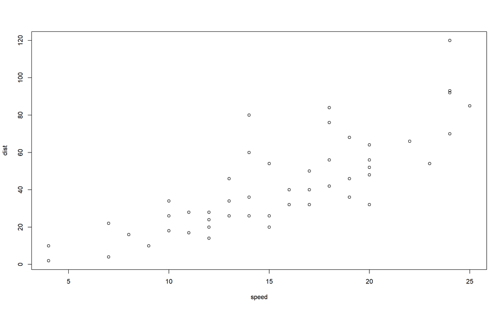

```r
plot(cars)
```

## 6.4 `read.csv()`

Reads a file in table format and creates a data frame from it, with cases corresponding to lines and variables to fields in the file.

```r
test1 <- c(1:5, "6,7", "8,9,10")
tf <- tempfile()
writeLines(test1, tf)

read.csv(tf, fill = TRUE) # 1 column
```

```
##   X1
## 1  2
## 2  3
## 3  4
## 4  5
## 5  6
## 6  7
## 7  8
## 8  9
## 9 10
```

```r
ncol <- max(count.fields(tf, sep = ","))
read.csv(tf, fill = TRUE, header = FALSE,
         col.names = paste0("V", seq_len(ncol)))
```

```
##   V1 V2 V3
## 1  1 NA NA
## 2  2 NA NA
## 3  3 NA NA
## 4  4 NA NA
## 5  5 NA NA
## 6  6  7 NA
## 7  8  9 10
```

```r
unlink(tf)
```

## 6.5 `t()`

Given a matrix or data.frame x, t returns the transpose of x.

```r
cars
```

```
##    speed dist
## 1      4    2
## 2      4   10
## 3      7    4
## 4      7   22
## 5      8   16
## 6      9   10
## 7     10   18
## 8     10   26
## 9     10   34
## 10    11   17
## 11    11   28
## 12    12   14
## 13    12   20
## 14    12   24
```

[output cut: 36 more lines]

```r
t(cars)
```

```
##       [,1] [,2] [,3] [,4] [,5] [,6] [,7] [,8] [,9] [,10] [,11] [,12] [,13]
## speed    4    4    7    7    8    9   10   10   10    11    11    12    12
## dist     2   10    4   22   16   10   18   26   34    17    28    14    20
##       [,14] [,15] [,16] [,17] [,18] [,19] [,20] [,21] [,22] [,23] [,24] [,25]
## speed    12    12    13    13    13    13    14    14    14    14    15    15
## dist     24    28    26    34    34    46    26    36    60    80    20    26
##       [,26] [,27] [,28] [,29] [,30] [,31] [,32] [,33] [,34] [,35] [,36] [,37]
## speed    15    16    16    17    17    17    18    18    18    18    19    19
## dist     54    32    40    32    40    50    42    56    76    84    36    46
##       [,38] [,39] [,40] [,41] [,42] [,43] [,44] [,45] [,46] [,47] [,48] [,49]
## speed    19    20    20    20    20    20    22    23    24    24    24    24
## dist     68    32    48    52    56    64    66    54    70    92    93   120
##       [,50]
## speed    25
## dist     85
```

## 6.6 `sum()`, `sqrt()`, `sd()`, `log()`

En este caso ponemos en conjunto varias funciones que son usadas de manera matemática.

### 6.6.1 `sum()`

sum returns the sum of all the values present in its arguments.

```r
sum(1,2,4)
```

```
## [1] 7
```

### 6.6.2 `sqrt()`

abs(x) computes the absolute value of x, sqrt(x) computes the (principal) square root of x, √{x}.

```r
sqrt(123434)
```

```
## [1] 351.3318
```

### 6.6.3 `sd()`

This function computes the standard deviation of the values in x. If na.rm is TRUE then missing values are removed before computation proceeds.

```r
sd(1:2) ^ 2
```

```
## [1] 0.5
```

### 6.6.4 `log()`

log computes logarithms, by default natural logarithms, log10 computes common (i.e., base 10) logarithms, and log2 computes binary (i.e., base 2) logarithms. The general form log(x, base) computes logarithms with base base.

```r
log(exp(3))
```

```
## [1] 3
```

## 6.7 `range()`

range returns a vector containing the minimum and maximum of all the given arguments.

```r
x <- c(123,345,345.345,1.1,0.1)
range(x)
```

```
## [1]   0.100 345.345
```

## 6.8 `ncol()`

nrow and ncol return the number of rows or columns present in x. NCOL and NROW do the same treating a vector as 1-column matrix, even a 0-length vector, compatibly with as.matrix() or cbind(), see the example.

```r
mtcars
```

```
##                      mpg cyl  disp  hp drat    wt  qsec vs am gear carb
## Mazda RX4           21.0   6 160.0 110 3.90 2.620 16.46  0  1    4    4
## Mazda RX4 Wag       21.0   6 160.0 110 3.90 2.875 17.02  0  1    4    4
## Datsun 710          22.8   4 108.0  93 3.85 2.320 18.61  1  1    4    1
## Hornet 4 Drive      21.4   6 258.0 110 3.08 3.215 19.44  1  0    3    1
## Hornet Sportabout   18.7   8 360.0 175 3.15 3.440 17.02  0  0    3    2
## Valiant             18.1   6 225.0 105 2.76 3.460 20.22  1  0    3    1
## Duster 360          14.3   8 360.0 245 3.21 3.570 15.84  0  0    3    4
## Merc 240D           24.4   4 146.7  62 3.69 3.190 20.00  1  0    4    2
## Merc 230            22.8   4 140.8  95 3.92 3.150 22.90  1  0    4    2
## Merc 280            19.2   6 167.6 123 3.92 3.440 18.30  1  0    4    4
## Merc 280C           17.8   6 167.6 123 3.92 3.440 18.90  1  0    4    4
## Merc 450SE          16.4   8 275.8 180 3.07 4.070 17.40  0  0    3    3
## Merc 450SL          17.3   8 275.8 180 3.07 3.730 17.60  0  0    3    3
## Merc 450SLC         15.2   8 275.8 180 3.07 3.780 18.00  0  0    3    3
## Cadillac Fleetwood  10.4   8 472.0 205 2.93 5.250 17.98  0  0    3    4
## Lincoln Continental 10.4   8 460.0 215 3.00 5.424 17.82  0  0    3    4
## Chrysler Imperial   14.7   8 440.0 230 3.23 5.345 17.42  0  0    3    4
## Fiat 128            32.4   4  78.7  66 4.08 2.200 19.47  1  1    4    1
## Honda Civic         30.4   4  75.7  52 4.93 1.615 18.52  1  1    4    2
## Toyota Corolla      33.9   4  71.1  65 4.22 1.835 19.90  1  1    4    1
## Toyota Corona       21.5   4 120.1  97 3.70 2.465 20.01  1  0    3    1
## Dodge Challenger    15.5   8 318.0 150 2.76 3.520 16.87  0  0    3    2
## AMC Javelin         15.2   8 304.0 150 3.15 3.435 17.30  0  0    3    2
## Camaro Z28          13.3   8 350.0 245 3.73 3.840 15.41  0  0    3    4
## Pontiac Firebird    19.2   8 400.0 175 3.08 3.845 17.05  0  0    3    2
## Fiat X1-9           27.3   4  79.0  66 4.08 1.935 18.90  1  1    4    1
## Porsche 914-2       26.0   4 120.3  91 4.43 2.140 16.70  0  1    5    2
## Lotus Europa        30.4   4  95.1 113 3.77 1.513 16.90  1  1    5    2
## Ford Pantera L      15.8   8 351.0 264 4.22 3.170 14.50  0  1    5    4
## Ferrari Dino        19.7   6 145.0 175 3.62 2.770 15.50  0  1    5    6
## Maserati Bora       15.0   8 301.0 335 3.54 3.570 14.60  0  1    5    8
## Volvo 142E          21.4   4 121.0 109 4.11 2.780 18.60  1  1    4    2
```

```r
ncol(mtcars)
```

```
## [1] 11
```

## 6.9 `nrow()`

nrow and ncol return the number of rows or columns present in x. NCOL and NROW do the same treating a vector as 1-column matrix, even a 0-length vector, compatibly with as.matrix() or cbind(), see the example.

```r
mtcars
```

```
##                      mpg cyl  disp  hp drat    wt  qsec vs am gear carb
## Mazda RX4           21.0   6 160.0 110 3.90 2.620 16.46  0  1    4    4
## Mazda RX4 Wag       21.0   6 160.0 110 3.90 2.875 17.02  0  1    4    4
## Datsun 710          22.8   4 108.0  93 3.85 2.320 18.61  1  1    4    1
## Hornet 4 Drive      21.4   6 258.0 110 3.08 3.215 19.44  1  0    3    1
## Hornet Sportabout   18.7   8 360.0 175 3.15 3.440 17.02  0  0    3    2
## Valiant             18.1   6 225.0 105 2.76 3.460 20.22  1  0    3    1
## Duster 360          14.3   8 360.0 245 3.21 3.570 15.84  0  0    3    4
## Merc 240D           24.4   4 146.7  62 3.69 3.190 20.00  1  0    4    2
## Merc 230            22.8   4 140.8  95 3.92 3.150 22.90  1  0    4    2
## Merc 280            19.2   6 167.6 123 3.92 3.440 18.30  1  0    4    4
## Merc 280C           17.8   6 167.6 123 3.92 3.440 18.90  1  0    4    4
## Merc 450SE          16.4   8 275.8 180 3.07 4.070 17.40  0  0    3    3
## Merc 450SL          17.3   8 275.8 180 3.07 3.730 17.60  0  0    3    3
## Merc 450SLC         15.2   8 275.8 180 3.07 3.780 18.00  0  0    3    3
## Cadillac Fleetwood  10.4   8 472.0 205 2.93 5.250 17.98  0  0    3    4
## Lincoln Continental 10.4   8 460.0 215 3.00 5.424 17.82  0  0    3    4
## Chrysler Imperial   14.7   8 440.0 230 3.23 5.345 17.42  0  0    3    4
## Fiat 128            32.4   4  78.7  66 4.08 2.200 19.47  1  1    4    1
## Honda Civic         30.4   4  75.7  52 4.93 1.615 18.52  1  1    4    2
## Toyota Corolla      33.9   4  71.1  65 4.22 1.835 19.90  1  1    4    1
## Toyota Corona       21.5   4 120.1  97 3.70 2.465 20.01  1  0    3    1
## Dodge Challenger    15.5   8 318.0 150 2.76 3.520 16.87  0  0    3    2
## AMC Javelin         15.2   8 304.0 150 3.15 3.435 17.30  0  0    3    2
## Camaro Z28          13.3   8 350.0 245 3.73 3.840 15.41  0  0    3    4
## Pontiac Firebird    19.2   8 400.0 175 3.08 3.845 17.05  0  0    3    2
## Fiat X1-9           27.3   4  79.0  66 4.08 1.935 18.90  1  1    4    1
## Porsche 914-2       26.0   4 120.3  91 4.43 2.140 16.70  0  1    5    2
## Lotus Europa        30.4   4  95.1 113 3.77 1.513 16.90  1  1    5    2
## Ford Pantera L      15.8   8 351.0 264 4.22 3.170 14.50  0  1    5    4
## Ferrari Dino        19.7   6 145.0 175 3.62 2.770 15.50  0  1    5    6
## Maserati Bora       15.0   8 301.0 335 3.54 3.570 14.60  0  1    5    8
## Volvo 142E          21.4   4 121.0 109 4.11 2.780 18.60  1  1    4    2
```

```r
nrow(mtcars)
```

```
## [1] 32
```

## 6.10 `colnames()`

Retrieve or set the row or column names of a matrix-like object.

```r
colnames(mtcars)
```

```
##  [1] "mpg"  "cyl"  "disp" "hp"   "drat" "wt"   "qsec" "vs"   "am"   "gear"
## [11] "carb"
```

## 6.11 `rownames()`

Retrieve or set the row or column names of a matrix-like object.

```r
rownames(mtcars)
```

```
##  [1] "Mazda RX4"           "Mazda RX4 Wag"       "Datsun 710"
##  [4] "Hornet 4 Drive"      "Hornet Sportabout"   "Valiant"
##  [7] "Duster 360"          "Merc 240D"           "Merc 230"
## [10] "Merc 280"            "Merc 280C"           "Merc 450SE"
## [13] "Merc 450SL"          "Merc 450SLC"         "Cadillac Fleetwood"
## [16] "Lincoln Continental" "Chrysler Imperial"   "Fiat 128"
## [19] "Honda Civic"         "Toyota Corolla"      "Toyota Corona"
## [22] "Dodge Challenger"    "AMC Javelin"         "Camaro Z28"
## [25] "Pontiac Firebird"    "Fiat X1-9"           "Porsche 914-2"
## [28] "Lotus Europa"        "Ford Pantera L"      "Ferrari Dino"
## [31] "Maserati Bora"       "Volvo 142E"
```

## 6.12 `sort()`

Sort (or order) a vector or factor (partially) into ascending or descending order. For ordering along more than one variable, e.g., for sorting data frames, see order.

```r
x <- swiss$Education[1:25]
x; sort(x); sort(x, partial = c(10, 15))
```

```
##  [1] 12  9  5  7 15  7  7  8  7 13  6 12  7 12  5  2  8 28 20  9 10  3 12  6  1
```

```
##  [1]  1  2  3  5  5  6  6  7  7  7  7  7  8  8  9  9 10 12 12 12 12 13 15 20 28
```

```
##  [1]  3  2  5  5  1  6  6  7  7  7  7  8  7  8  9  9 10 12 12 12 12 20 28 13 15
```

## 6.13 `View()`

Invoke a spreadsheet-style data viewer on a matrix-like R object.

```
View(mtcars)
```

# 7 Ejercicios

En este apartado usaremos lo que hemos aprendido en las secciones anteriores de manera sencilla y básica. Es importante aclarar que algunas funciones no las hemos visto en esta introducción, de modo que deberás de buscar las funciones o las estrategias necesarias para poder cumplir con las instrucciones. En la sub-sección que sigue, se incluirán respuestas de cómo hacer lo que se te pide, pero debes de tener en cuenta que existen infinidad de maneras de realizar una misma tarea; **siempre y cuando el resultado sea el mismo, no te preocupes.**

1. Carga la base de datos llamada “Daphnia_data.csv” que puedes encontrar en la carpeta de “Datos” y asígnalo en un objeto llamado daphnia.
2. Demuestra de qué tipo es nuestro objeto daphnia.
3. Genera una columna nueva llamada “new_col” que tenga una repetición de los números 1:3 hasta llenar todos los renglones.
4. Elimina las últimas 5 filas de nuestro objeto y asígnalo a un nuevo objeto llamado “daphnia_mod”.
5. Determina la diferencia de promedios de crecimiento entre nuestro dataframe `dpahnia` original y el modificado.

## 7.1 Respuestas

```r
# 1. Carga la base de datos llamada "Daphnia_data.csv" que puedes encontrar en la carpeta de "Datos" y asígnalo en un objeto llamado daphnia.

daphnia <- read.csv("Datos/Daphnia_data.csv")
```

```r
# 2. Demuestra de qué tipo es nuestro objeto daphnia.

class(daphnia)
```

```
## [1] "data.frame"
```

```r
# 3. Genera una columna nueva llamada "new_col" que tenga una repetición de los números 1:3 hasta llenar todos los renglones.

## Vamos a ver cuántos renglones hay y cuánmtas veces cabe nuestra repetición de números en los renglones
numb <- nrow(daphnia)
capacity <- numb/3
## Asignar una nueva columna
daphnia["new_col"] <- rep(1:3, 24)
## Corroborar que esté la nueva columna
head(daphnia)
```

```
##   Growth.rate Water Detergent Daphnia new_col
## 1    2.919086  Tyne    BrandA  Clone1       1
## 2    2.492904  Tyne    BrandA  Clone1       2
## 3    3.021804  Tyne    BrandA  Clone1       3
## 4    2.350874  Tyne    BrandA  Clone2       1
## 5    3.148174  Tyne    BrandA  Clone2       2
## 6    4.423853  Tyne    BrandA  Clone2       3
```

```r
# 4. Elimina las últimas 5 filas de nuestro objeto y asígnalo a un nuevo objeto llamado "daphnia_mod".

daphnia_mod <- daphnia[-c((nrow(daphnia)-4):nrow(daphnia)),]
tail(daphnia_mod)
```

```
##    Growth.rate Water Detergent Daphnia new_col
## 62    3.467042  Wear    BrandC  Clone3       2
## 63    5.028927  Wear    BrandC  Clone3       3
## 64    2.307174  Wear    BrandD  Clone1       1
## 65    2.962274  Wear    BrandD  Clone1       2
## 66    2.699762  Wear    BrandD  Clone1       3
## 67    6.569412  Wear    BrandD  Clone2       1
```

**Parece que quitamos solo 4 filas, pero mira bien el número final y compáralo con el inicial**

```r
# 5. Determina la diferencia de promedios de crecimiento entre nuestro dataframe `dpahnia` original y el modificado.

# Obetener las medias de crecimiento de cada una de las dataframes
mean_1 <- mean(daphnia$Growth.rate)
mean_2 <- mean(daphnia_mod$Growth.rate)

# Hacer la compración
mean_1-mean_2
```

```
## [1] 0.0006595231
```

# 8 Recursos adicionales

1. https://www.r-project.org
2. http://www.cookbook-r.com
3. https://www.statmethods.net
4. https://r-coder.com/introduccion-r/
5. https://www.tutorialspoint.com/r/index.htm

# 9 Bibliografía

[^1]: https://www.r-project.org
[^2]: Gentleman, Robert; Carey, Vincent J.; Huber, Wolfgang; Irizarry, Rafael A.; Dudoit, Sandrine (2005). [Statistics for Biology and Health] Bioinformatics and Computational Biology Solutions Using R and Bioconductor, 10.1007/0-387-29362-0(), doi:10.1007/0-387-29362-0.
[^3]: https://www.geeksforgeeks.org/data-structures-in-r-programming/
[^4]: https://bookdown.org/jboscomendoza/r-principiantes4/matrices-y-arrays.html
[^5]: https://www.datamentor.io/r-programming/operator/